# SI 618 Homework #4

## Taylor Swift songs

Last updated 2023-10-04

The dataset for this assignment is from https://www.kaggle.com/datasets/jarredpriester/taylor-swift-spotify-dataset/data.

**NOTE**: Use the dataset from Canvas rather than the dataset from Kaggle, which is updated frequently and may change while you are completing this assignment.

This dataset consist of data from Spotify's API on all albums listed on Spotify for Taylor Swift. I set up the dataset to update monthly so that if any albums get added it will get added to the dataset too. At first it may look like there are song duplicates but I checked and all song IDs are unique.

The columns in this dataset are:

name - the name of the song

album - the name of the album

release_date - the day month and year the album was released

track number - the order the song appears on the album

id - the Spotify id for the song

uri - the Spotify uri for the song

acousticness - A confidence measure from 0.0 to 1.0 of whether the track is acoustic. 1.0 represents high confidence the track is acoustic.

danceability - Danceability describes how suitable a track is for dancing based on a combination of musical elements including tempo, rhythm stability, beat strength, and overall regularity. A value of 0.0 is least danceable and 1.0 is most danceable.

energy - Energy is a measure from 0.0 to 1.0 and represents a perceptual measure of intensity and activity. Typically, energetic tracks feel fast, loud, and noisy. For example, death metal has high energy, while a Bach prelude scores low on the scale. Perceptual features contributing to this attribute include dynamic range, perceived loudness, timbre, onset rate, and general entropy.

instrumentalness - Predicts whether a track contains no vocals. "Ooh" and "aah" sounds are treated as instrumental in this context. Rap or spoken word tracks are clearly "vocal". The closer the instrumentalness value is to 1.0, the greater likelihood the track contains no vocal content. Values above 0.5 are intended to represent instrumental tracks, but confidence is higher as the value approaches 1.0.

liveness - Detects the presence of an audience in the recording. Higher liveness values represent an increased probability that the track was performed live. A value above 0.8 provides strong likelihood that the track is live.

loudness - The overall loudness of a track in decibels (dB). Loudness values are averaged across the entire track and are useful for comparing relative loudness of tracks. Loudness is the quality of a sound that is the primary psychological correlate of physical strength (amplitude). Values typically range between -60 and 0 db.

speechiness - detects the presence of spoken words in a track. The more exclusively speech-like the recording (e.g. talk show, audio book, poetry), the closer to 1.0 the attribute value. Values above 0.66 describe tracks that are probably made entirely of spoken words. Values between 0.33 and 0.66 describe tracks that may contain both music and speech, either in sections or layered, including such cases as rap music. Values below 0.33 most likely represent music and other non-speech-like tracks.

tempo - The overall estimated tempo of a track in beats per minute (BPM). In musical terminology, tempo is the speed or pace of a given piece and derives directly from the average beat duration.

valence - A measure from 0.0 to 1.0 describing the musical positiveness conveyed by a track. Tracks with high valence sound more positive (e.g. happy, cheerful, euphoric), while tracks with low valence sound more negative (e.g. sad, depressed, angry).

popularity - the popularity of the song from 0 to 100

duration_ms - The duration of the track in milliseconds.

We are going to refer to the tracks' properties of danceability, energy, instrumentalness, liveness, loudness, speechiness, tempo, and valence as "features" of the tracks.

Each of the questions is worth the same number of points, except for the final bonus question, which is worth up to an additional 2 points (out of 100). Points will be allocated according to the following rubric:

- 90-100%: Question is correctly and completely answered. Answer consists of well-written code that conforms to [PEP 8](https://www.python.org/dev/peps/pep-0008/) guidelines and is accompanied by a written interpretation in a Markdown block. Written interpretation does not contain spelling, grammar or stylistic errors (see [Strunk & White](https://drive.google.com/file/d/1L0P7xJwjUGBvyb49mL3dw1Bt7hzRTiTl/view?usp=sharing) for a detailed specifications). Minor problems, such as formatting, incorrect submissions, missing names, etc. will result in less than 100%.
- 75-85% : Answer is mostly complete and correct; two or fewer noticeable omissions or errors. Minor stylistic flaws, either in code or in written interpretation.
- 50-70%: Answer has significant omissions or errors; Noticeable departure from PEP-8 guildelines and/or moderate spelling, grammar, or style issues in written interpretations.
- 25-45%: Question is perfunctorily attempted. Substantial parts are missing or incorrect.
- 0 points: Question not attempted.

Be sure to include interpretations of your results for each question.

Q1: Show the distribution of the popularity of the songs. Then exclude the songs that are from karaoke albums (i.e., the album name contains "karaoke"). Show the distribution of the popularity of the songs. What is the difference between the two distributions?

```python
import numpy as np
import pandas as pd

from sklearn.model_selection import train_test_split
from sklearn.preprocessing import PolynomialFeatures
from sklearn.linear_model import Ridge
from sklearn.svm import SVR
from sklearn.linear_model import LinearRegression
from sklearn.preprocessing import StandardScaler
from sklearn.pipeline import Pipeline
from sklearn.model_selection import KFold
from sklearn.linear_model import LogisticRegression
from sklearn.metrics import mean_squared_error

import xgboost as xgb

import matplotlib.pyplot as plt
# plt.style.use("dark_background")
import seaborn as sns
import plotly.express as px
import warnings
warnings.filterwarnings('ignore')
```

```python
# read csv
song = pd.read_csv("taylor_swift_spotify.csv",
                   index_col=0)
song.tail(3)
```

|  | name | album | release_date | track_number | id | uri | acousticness | danceability | energy | instrumentalness | liveness | loudness | speechiness | tempo | valence | popularity | duration_ms |
| --- | --- | --- | --- | --- | --- | --- | --- | --- | --- | --- | --- | --- | --- | --- | --- | --- | --- |
| 1262 | I'm Only Me When I'm With You - Instrumental w... | Taylor Swift Karaoke | 2006-10-24 | 12 | 4Vg8MqpDQFDfKmXdpO1jD3 | spotify:track:4Vg8MqpDQFDfKmXdpO1jD3 | 0.000053 | 0.541 | 0.796 | 0.820 | 0.3260 | -8.833 | 0.0306 | 144.004 | 0.847 | 5 | 223386 |
| 1263 | Invisible - Instrumental w/ BG vocals | Taylor Swift Karaoke | 2006-10-24 | 13 | 7Fg8MxumrT8axFZVzN1MtT | spotify:track:7Fg8MxumrT8axFZVzN1MtT | 0.259000 | 0.575 | 0.279 | 0.572 | 0.0941 | -12.066 | 0.0286 | 96.007 | 0.118 | 4 | 206480 |
| 1264 | A Perfectly Good Heart - Instrumental w/ BG vo... | Taylor Swift Karaoke | 2006-10-24 | 14 | 12QHKhw9K9yJOJ1nKRiBYI | spotify:track:12QHKhw9K9yJOJ1nKRiBYI | 0.000065 | 0.468 | 0.658 | 0.903 | 0.1800 | -8.908 | 0.0309 | 155.995 | 0.310 | 4 | 227920 |

```python
song.shape
```

```
(1265, 17)
```

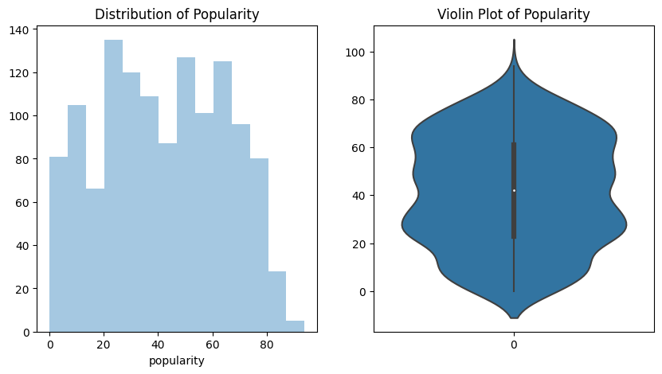

```python
# create subplots, dist and violin plot of popularity
fig, ax = plt.subplots(1, 2, figsize=(10, 5))
sns.distplot(song["popularity"], kde=False, ax=ax[0])
ax[0].set_title("Distribution of Popularity")
sns.violinplot(song["popularity"], ax=ax[1])
ax[1].set_title("Violin Plot of Popularity")
plt.show()
```

```python
# drop karaoke songs
pattern = r"[Kk]araoke"
karaoke = song[song["album"].str.contains(pattern)]
song = song[~song["album"].str.contains(pattern)]
song.shape
```

```
(1075, 17)
```

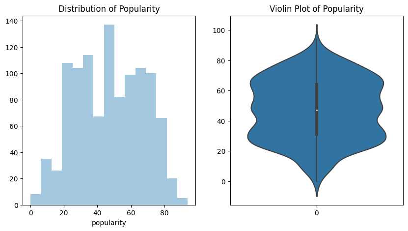

```python
# create subplots, dist and violin plot of popularity
fig, ax = plt.subplots(1, 2, figsize=(10, 5))
sns.distplot(song["popularity"], kde=False, ax=ax[0])
ax[0].set_title("Distribution of Popularity")
sns.violinplot(song["popularity"], ax=ax[1])
ax[1].set_title("Violin Plot of Popularity")
plt.show()
```

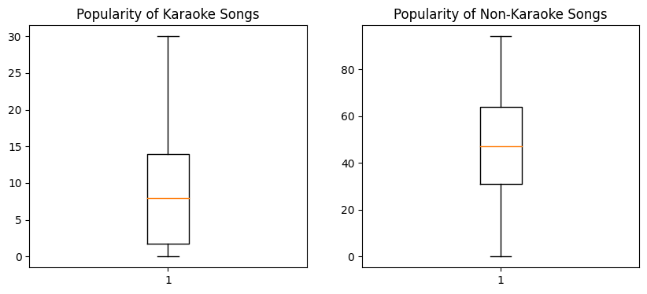

```python
# subplot boxplot of popularity of Karaoke and non-Karaoke songs
fig, ax = plt.subplots(1, 2, figsize=(10, 4))
ax[0].boxplot(karaoke["popularity"])
ax[0].set_title("Popularity of Karaoke Songs")
ax[1].boxplot(song["popularity"])
ax[1].set_title("Popularity of Non-Karaoke Songs")
plt.show()
```

```python
p1 = karaoke["popularity"].mean().__round__(2)
p2 = song["popularity"].mean().__round__(2)
print(f"Mean Karoke popularity: {p1} and Mean Non-Karoke popularity: {p2}")
```

```
Mean Karoke popularity: 9.1 and Mean Non-Karoke popularity: 47.28
```

- Distribution of songs with Popularity more than 70 seems to remain unchanged
- The overall trend resembles a normal distribution in the subset after dropping Karaoke albums
- Much of the weight between 0 - 20 popularity seems to have been decreased, showing that the Karaoke albums were on the lower end of the popularity spectrum.
- Some reasons why:
  - Karaoke albums featuring Taylor Swift's songs are less popular than her original releases. Fans prefer her authentic voice and emotional interpretation.
  - Original versions boast higher production quality and marketing efforts.
  - Karaoke versions serve a different purpose for singing practice and entertainment.

### IMPORTANT NOTE: the remainder of the questions are based on the songs that are NOT from karaoke albums.

Q2: Report the average track duration for each album. You answer should be in mm:ss (minutes:seconds) format rather than the milliseconds that are reported in the original dataset.

```python
# count unique albums
t = song["album"].nunique()
print(f"Total unique albums are: {t}")
```

```
Total unique albums are: 35
```

```python
# song group by album on duration_ms
album = pd.DataFrame(song.groupby("album")["duration_ms"].mean()\
                    .sort_values(ascending=False))

album["sec"] = (album["duration_ms"] / 1000).astype(int)
album['min'] = album['sec'] // 60
album['sec'] = album['sec'] % 60

# add 0 to sec if sec < 10
album["sec"] = np.where(album["sec"] < 10, "0" + album["sec"].astype(str),
                        album["sec"].astype(str))

album["duration"] = "0" + album["min"].astype(str)\
    + ":" + album["sec"].astype(str)

# album.drop(columns=["duration_ms", "sec", "min"], inplace=True)
album[['duration']].head()
```

| album | duration |
| --- | --- |
| Speak Now World Tour Live | 04:57 |
| Speak Now (US Version) | 04:47 |
| Speak Now | 04:47 |
| Speak Now (Japanese Version) | 04:46 |
| Speak Now (Deluxe Package) | 04:35 |

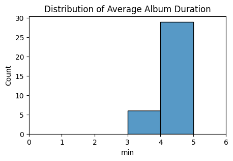

```python
# distplot for min
plt.figure(figsize=(5, 3))
sns.histplot(album["min"]+1, kde=False, binwidth=1)
plt.xlim(0, 6)
plt.title("Distribution of Average Album Duration")
plt.show()
```

We see that most Taylor Swift songs fall between 3 to 5 minutes in duration to align with radio airplay preferences, maintain listener engagement, and adhere to pop music standards. This duration is commercially viable and follows a common song structure.

Q3: Show a heatmap of the correlations between the features. Use a diverging colormap with white in the middle (i.e. white at a correlation of 0.0).

```python
# get numerical columns
num_cols = song.select_dtypes(include=np.number).columns.to_list()
num_cols.remove('duration_ms')
print(num_cols)
```

```
['track_number', 'acousticness', 'danceability', 'energy', 'instrumentalness', 'liveness', 'loudness', 'speechiness', 'tempo', 'valence', 'popularity']
```

My opinion why Duration Should Not Be Considered as a Feature:

- Doesn't capture the diversity of musical styles and lyrical themes that short and long songs can convey.
- Artists may create songs of various durations intentionally to express a specific message or emotion.
- Listener preferences for song duration vary widely, making it challenging to generalize its impact on all audiences.

Other opinion why Duration Should Be Considered as a Feature:

- Impacts listener engagement, with shorter songs preferred for quick listening and longer songs for immersive experiences.
- Influences radio airplay, Reels, Tiktok as many stations have specific time slots for songs within certain duration ranges.
- Affects streaming recommendations, with platforms considering user listening habits and available time.

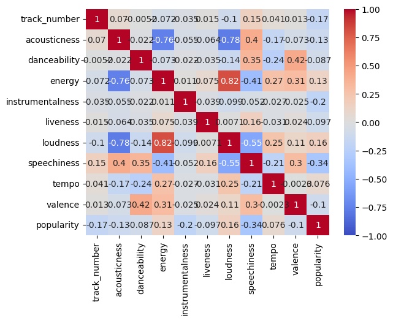

```python
# correlation matrix of song
corr = song[num_cols].corr()
sns.heatmap(corr, cmap="coolwarm", annot=True,
            vmin=-1, vmax=1)
```

I am stating few examples for both the above cases.

```python
# Songs with higher loudness, tempo and energy and their popularity
print(f"Range of loudness is: {song['loudness'].min()}"
      + f" to {song['loudness'].max()}")
print(f"Range of tempo is: {song['tempo'].min()} to {song['tempo'].max()}")
print(f"Range of energy is: {song['energy'].min()} to {song['energy'].max()}")

song[["loudness", "tempo", "energy", "popularity"
      ]].sort_values(by="popularity",
                     ascending=False).head(5)
```

```
Range of loudness is: -17.932 to -1.953
Range of tempo is: 47.607 to 208.918
Range of energy is: 0.118 to 0.95
```

|  | loudness | tempo | energy | popularity |
| --- | --- | --- | --- | --- |
| 42 | -6.571 | 97.008 | 0.643 | 94 |
| 366 | -5.707 | 169.994 | 0.702 | 90 |
| 401 | -6.719 | 135.917 | 0.534 | 89 |
| 40 | -10.489 | 96.985 | 0.436 | 89 |
| 334 | -8.588 | 130.033 | 0.581 | 88 |

```python
# Danceable songs and valence and speechiness.
print(f"Range of valence is: {song['valence'].min()}"
      + f" to {song['valence'].max()}")
print(f"Range of speechiness is: {song['speechiness'].min()}"
      + f" to {song['speechiness'].max()}")

song[["danceability", "valence", "speechiness"
      ]].sort_values(by="danceability",
                     ascending=False).head(5)
```

```
Range of valence is: 0.0374 to 0.943
Range of speechiness is: 0.0231 to 0.957
```

|  | danceability | valence | speechiness |
| --- | --- | --- | --- |
| 370 | 0.897 | 0.416 | 0.0569 |
| 27 | 0.875 | 0.155 | 0.3610 |
| 60 | 0.870 | 0.176 | 0.4020 |
| 7 | 0.870 | 0.160 | 0.3640 |
| 1127 | 0.843 | 0.825 | 0.0317 |

Q4: List the top 5 correlations between the features of the songs.

```python
a = song[num_cols].corr().unstack().drop_duplicates().abs().sort_values(
    ascending=False)[1:6].index.tolist()

corr_list = []
col_1 = []
col_2 = []

for i in range(5):
    corr_list.append(song[num_cols].corr()[a[i][0]][a[i][1]])
    col_1.append(a[i][0])
    col_2.append(a[i][1])

# make dataframe of a and corr_list
corr_df = pd.DataFrame({'var1':col_1, 'var2':col_2, 'corr':corr_list})
corr_df
```

|  | var1 | var2 | corr |
| --- | --- | --- | --- |
| 0 | energy | loudness | 0.817729 |
| 1 | acousticness | loudness | -0.777471 |
| 2 | acousticness | energy | -0.756873 |
| 3 | loudness | speechiness | -0.549766 |
| 4 | danceability | valence | 0.415063 |

```python
song_list = ["Shake It Off", "Teardrops On My Guitar", "cardigan",
             "All Too Well", "Love Story"]
song[song["name"].isin(song_list)][["name", "energy", "loudness",
                                    "acousticness", "speechiness",
                                    "valence", "danceability"]].groupby(
    "name").mean().reset_index()
```

|  | name | energy | loudness | acousticness | speechiness | valence | danceability |
| --- | --- | --- | --- | --- | --- | --- | --- |
| 0 | All Too Well | 0.608200 | -7.803000 | 0.039520 | 0.024320 | 0.332800 | 0.602000 |
| 1 | Love Story | 0.700625 | -4.493250 | 0.103425 | 0.030138 | 0.302000 | 0.618375 |
| 2 | Shake It Off | 0.792500 | -5.399000 | 0.060400 | 0.165000 | 0.942500 | 0.647250 |
| 3 | Teardrops On My Guitar | 0.550500 | -6.313500 | 0.017200 | 0.025750 | 0.162500 | 0.513500 |
| 4 | cardigan | 0.580667 | -8.582667 | 0.533000 | 0.042233 | 0.545333 | 0.612667 |

These examples demonstrate how Taylor Swift's diverse music catalog can be used to illustrate the correlations between different musical features and the characteristics of her songs.

Q5: Does the position of the track on the album (i.e. track number) have an effect on the popularity of the song? Use both visual and statistical evidence to support your answer.

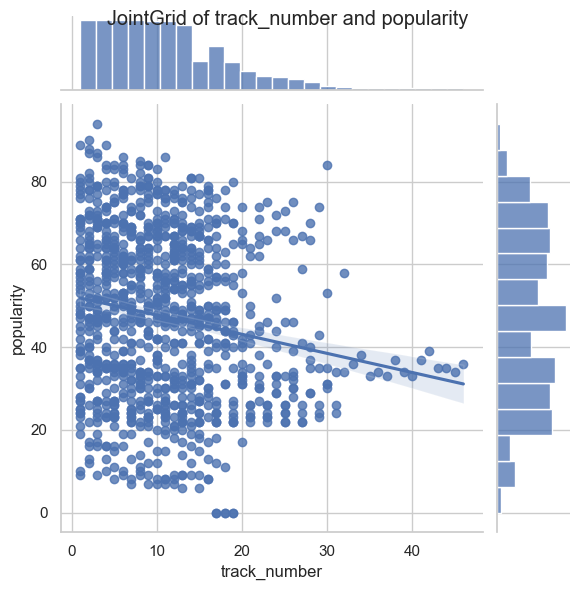

```python
sns.set(style="whitegrid")

g = sns.JointGrid(data=song, x="track_number", y="popularity")

sns.regplot(data=song, x="track_number",
            y="popularity", ax=g.ax_joint)
sns.histplot(data=song, x="track_number", ax=g.ax_marg_x)
sns.histplot(data=song, y="popularity", ax=g.ax_marg_y)

g.set_axis_labels("track_number", "popularity")
g.fig.suptitle("JointGrid of track_number and popularity")
```

Yes, from the JointGrid plot, visually we can see that the image shows that there is a negative relationship between popularity and track number. This means that the popularity of a song tends to decrease as the track number increases. There are a few possible explanations for this relationship, including people's shorter attention spans, their familiarity with the songs, and the quality of the songs.

```python
import statsmodels.api as sm
import statsmodels.formula.api as smf

model0 = smf.ols(
    formula= "Q('popularity') ~ Q('track_number')",
    data=song).fit()
model0.summary()
```

OLS Regression Results

| Dep. Variable: | Q('popularity') | R-squared: | 0.030 |
| --- | --- | --- | --- |
| Model: | OLS | Adj. R-squared: | 0.029 |
| Method: | Least Squares | F-statistic: | 33.51 |
| Date: | Wed, 11 Oct 2023 | Prob (F-statistic): | 9.28e-09 |
| Time: | 21:10:03 | Log-Likelihood: | -4732.3 |
| No. Observations: | 1075 | AIC: | 9469. |
| Df Residuals: | 1073 | BIC: | 9479. |
| Df Model: | 1 |  |  |
| Covariance Type: | nonrobust |  |  |

|  | coef | std err | t | P>\|t\| | [0.025 | 0.975] |
| --- | --- | --- | --- | --- | --- | --- |
| Intercept | 52.3687 | 1.066 | 49.111 | 0.000 | 50.276 | 54.461 |
| Q('track_number') | -0.4624 | 0.080 | -5.789 | 0.000 | -0.619 | -0.306 |

| Omnibus: | 115.980 | Durbin-Watson: | 0.414 |
| --- | --- | --- | --- |
| Prob(Omnibus): | 0.000 | Jarque-Bera (JB): | 34.834 |
| Skew: | -0.106 | Prob(JB): | 2.73e-08 |
| Kurtosis: | 2.144 | Cond. No. | 23.7 |

Notes:  
[1] Standard Errors assume that the covariance matrix of the errors is correctly specified.

The statistical results determine that we reject Null-hypothesis as the p value is less than 0.05 which is threshold. Therefore the regression is statistically significant. In other words, the data provides strong evidence that the popularity of a song decreases as the track number increases. This is consistent with the findings from the visual part, which showed that there is a negative correlation between popularity and track number.

Q6: Are popular songs more danceable? Divide the songs into popular (i.e. those with a popularity rating of 60 or higher) and less popular (i.e. those with a popularity rating of less than 60). Conduct an ANOVA test for the two groups of data based on danceability feature. Are they statistically significant?

```python
# categorise based on popularity
song["popularity_cat"] = pd.cut(song["popularity"],
                                bins=[0, 59, 100],
                                labels=[0, 1])
```

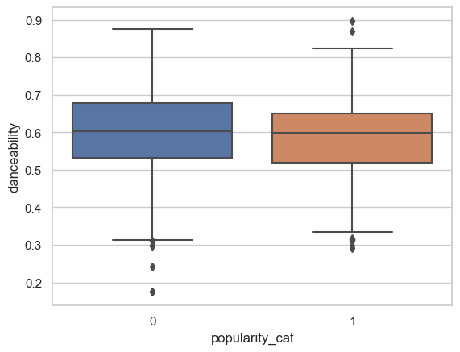

```python
sns.boxplot(x='popularity_cat', y='danceability', data=song)
```

```python
# insert your code here
import statsmodels.api as sm
import statsmodels.formula.api as smf
from statsmodels.formula.api import ols

model2 = ols('danceability ~ popularity_cat', data=song).fit()
model2.summary()
```

OLS Regression Results

| Dep. Variable: | danceability | R-squared: | 0.004 |
| --- | --- | --- | --- |
| Model: | OLS | Adj. R-squared: | 0.003 |
| Method: | Least Squares | F-statistic: | 4.037 |
| Date: | Wed, 11 Oct 2023 | Prob (F-statistic): | 0.0448 |
| Time: | 21:10:03 | Log-Likelihood: | 821.24 |
| No. Observations: | 1069 | AIC: | -1638. |
| Df Residuals: | 1067 | BIC: | -1629. |
| Df Model: | 1 |  |  |
| Covariance Type: | nonrobust |  |  |

|  | coef | std err | t | P>\|t\| | [0.025 | 0.975] |
| --- | --- | --- | --- | --- | --- | --- |
| Intercept | 0.5984 | 0.004 | 143.337 | 0.000 | 0.590 | 0.607 |
| popularity_cat[T.1] | -0.0148 | 0.007 | -2.009 | 0.045 | -0.029 | -0.000 |

| Omnibus: | 17.286 | Durbin-Watson: | 1.755 |
| --- | --- | --- | --- |
| Prob(Omnibus): | 0.000 | Jarque-Bera (JB): | 17.751 |
| Skew: | -0.296 | Prob(JB): | 0.000140 |
| Kurtosis: | 3.218 | Cond. No. | 2.42 |

Notes:  
[1] Standard Errors assume that the covariance matrix of the errors is correctly specified.

Hypotheses:

Null hypothesis: The mean danceability of the two groups is equal.

Alternative hypothesis: The mean danceability of the two groups is not equal.

Interpretation:

The p-value is 0.0448, which is less than the critical value at a significance level of 0.05. This means that we reject the null hypothesis and conclude that there is a statistically significant difference in mean danceability between the two groups.

Conclusion:

There is a statistically significant difference in danceability between the two groups.

Q7: Create a regression model with "popularity" as the dependent variable and "liveness" as the predictor variable. Report the following:

1. Coefficient of determination (i.e. $r^2$)
2. Whether the regression is statistically significant
3. An estimate for the value of "popularity" when the value of "liveness" is 0.22.

```python
model3 = smf.ols(
    formula= "Q('popularity') ~ Q('liveness')",
    data=song).fit()
model3.summary()
```

OLS Regression Results

| Dep. Variable: | Q('popularity') | R-squared: | 0.009 |
| --- | --- | --- | --- |
| Model: | OLS | Adj. R-squared: | 0.008 |
| Method: | Least Squares | F-statistic: | 10.12 |
| Date: | Wed, 11 Oct 2023 | Prob (F-statistic): | 0.00150 |
| Time: | 21:10:03 | Log-Likelihood: | -4743.8 |
| No. Observations: | 1075 | AIC: | 9492. |
| Df Residuals: | 1073 | BIC: | 9502. |
| Df Model: | 1 |  |  |
| Covariance Type: | nonrobust |  |  |

|  | coef | std err | t | P>\|t\| | [0.025 | 0.975] |
| --- | --- | --- | --- | --- | --- | --- |
| Intercept | 49.8667 | 1.017 | 49.048 | 0.000 | 47.872 | 51.862 |
| Q('liveness') | -16.1986 | 5.091 | -3.182 | 0.002 | -26.188 | -6.210 |

| Omnibus: | 183.152 | Durbin-Watson: | 0.400 |
| --- | --- | --- | --- |
| Prob(Omnibus): | 0.000 | Jarque-Bera (JB): | 41.318 |
| Skew: | -0.056 | Prob(JB): | 1.07e-09 |
| Kurtosis: | 2.046 | Cond. No. | 8.57 |

Notes:  
[1] Standard Errors assume that the covariance matrix of the errors is correctly specified.

```python
-16.1986 * 0.22 + 49.8667
```

```
46.303008000000005
```

- R-squared: 0.009
- Reject Null-hypothesis as the p value is less than 0.05 which is threshold. Therefore the regression is statistically significant.
- 46.30 is an estimate for the value of "popularity" when the value of "liveness" is 0.22.

Q8: Due to intellectual property conflicts, Taylor Swift re-recorded some of her earlier albums, including `Fearless` and `Red`. We assume that re-recording her early albums will allow Taylor Swift to reclaim her artistry control, revisit the songs and make any changes she wants. Therefore, we want to see whether the new songs are more loved by the audiences by looking at the popularity score.

- The re-recorded ones have `(Taylor’s version)` at the end of the album name.

a) Create a visualization that shows the distribution of popularity scores of original vs. re-recorded songs. There are multiple visualizations that would be appropriate here. You can choose any of them. At a minimum, you should create one visualization. Creating additional ones can earn you additional points.

b) Is there a statistically significant difference between the popularity scores of the original and re-recorded songs? If so, which one is more popular? How much more popular is it, on average?

```python
pattern = r"\(Taylor's Version\)"

# add column in songs for TS
song["album_type"] = "Original"
song.loc[song["album"].str.contains(pattern), "album_type"] = "Re-recorded"

print(song["album_type"].value_counts())
```

```
album_type
Original       989
Re-recorded     86
Name: count, dtype: int64
```

```python
# give list of albums in original and re-recorded
print("Original albums :")
print(song.loc[song["album_type"] == "Original", "album"].unique())
print("Re-recorded albums :")
print(song.loc[song["album_type"] == "Re-recorded", "album"].unique())
```

```
Original albums :
['Midnights (3am Edition)' 'Midnights' 'evermore (deluxe version)'
 'evermore'
 'folklore: the long pond studio sessions (from the Disney+ special) [deluxe edition]'
 'folklore (deluxe version)' 'folklore' 'Lover' 'reputation'
 'reputation (Big Machine Radio Release Special)'
 'reputation Stadium Tour Surprise Song Playlist' '1989'
 '1989 (Big Machine Radio Release Special)' '1989 (Deluxe Edition)'
 '1989 (Deluxe)' 'Red' 'Red (Deluxe Edition)'
 'Red (Big Machine Radio Release Special)' 'Speak Now (Japanese Version)'
 'Speak Now World Tour Live' 'Speak Now'
 'Speak Now (Big Machine Radio Release Special)'
 'Speak Now (Deluxe Edition)' 'Speak Now (US Version)'
 'Speak Now (Deluxe Package)' 'Fearless'
 'Fearless (International Version)'
 'Fearless (Big Machine Radio Release Special)'
 'Fearless (Platinum Edition)' 'Fearless Platinum Edition'
 'Live From Clear Channel Stripped 2008' 'Taylor Swift'
 'Taylor Swift (Big Machine Radio Release Special)']
Re-recorded albums :
["Red (Taylor's Version)" "Fearless (Taylor's Version)"]
```

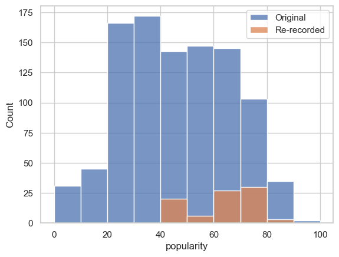

```python
# dist plot of popularity and album_type
sns.histplot(song.loc[song["album_type"] == "Original", "popularity"],
             label="Original", kde=False, binwidth=10)
sns.histplot(song.loc[song["album_type"] == "Re-recorded", "popularity"],
                label="Re-recorded", kde=False, binwidth=10)
plt.legend()
plt.show()
```

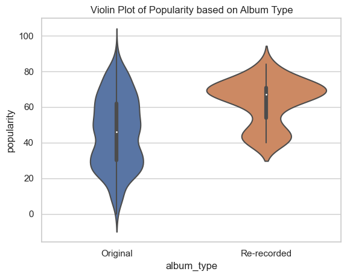

```python
# violin plot of popularity based on album_type
sns.violinplot(x="album_type", y="popularity", data=song)
plt.title("Violin Plot of Popularity based on Album Type")
plt.show()
```

```python
# original allbum - 0, re-recorded album - 1
song["album_cat"] = np.where(song["album_type"] == "Original", 0, 1)
```

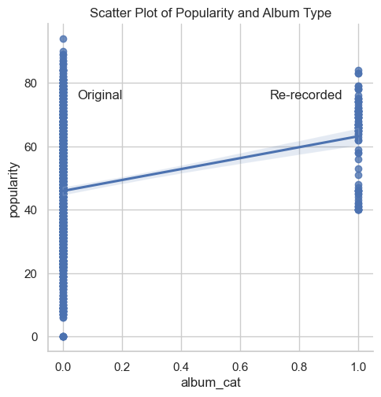

```python
# scatter plot and regression line of popularity and album_cat
sns.lmplot(x="album_cat", y="popularity", data=song)
plt.title("Scatter Plot of Popularity and Album Type")
plt.text(0.05, 75, "Original")
plt.text(0.70, 75, "Re-recorded")
plt.show()
```

- Only two albums "Red (Taylor's Version)" and "Fearless (Taylor's Version) are Re-recorded albums
- Number of songs in Re-recorded albums is 86 while those in the Original albums is 989, more than 10 times.
- As seen from the distribution plot, we can observe that Re-recorded albums have a high popularity as compared to Original albums.
- From the voilin plot, Median popularity of Original songs is about 45, while Median popularity of Re-recorded songs is about 70

```python
from scipy.stats import ttest_ind

# t-test of popularity based on album_type
ttest_ind(song.loc[song["album_type"] == "Original", "popularity"],
          song.loc[song["album_type"] == "Re-recorded", "popularity"])
```

```
TtestResult(statistic=-7.867927625810489, pvalue=8.760686477310353e-15, df=1073.0)
```

The p-value is less than 0.05, therefore we reject Null Hypothesis. So there is a statistially significant difference between the means of popularity scores of the original and re-recorded songs.

```python
# anova of popularity based on album_type
model4 = ols('popularity ~ album_cat', data=song).fit()
model4.summary()
```

OLS Regression Results

| Dep. Variable: | popularity | R-squared: | 0.055 |
| --- | --- | --- | --- |
| Model: | OLS | Adj. R-squared: | 0.054 |
| Method: | Least Squares | F-statistic: | 61.90 |
| Date: | Wed, 11 Oct 2023 | Prob (F-statistic): | 8.76e-15 |
| Time: | 21:10:04 | Log-Likelihood: | -4718.7 |
| No. Observations: | 1075 | AIC: | 9441. |
| Df Residuals: | 1073 | BIC: | 9451. |
| Df Model: | 1 |  |  |
| Covariance Type: | nonrobust |  |  |

|  | coef | std err | t | P>\|t\| | [0.025 | 0.975] |
| --- | --- | --- | --- | --- | --- | --- |
| Intercept | 45.8959 | 0.621 | 73.939 | 0.000 | 44.678 | 47.114 |
| album_cat | 17.2669 | 2.195 | 7.868 | 0.000 | 12.961 | 21.573 |

| Omnibus: | 95.211 | Durbin-Watson: | 0.424 |
| --- | --- | --- | --- |
| Prob(Omnibus): | 0.000 | Jarque-Bera (JB): | 30.070 |
| Skew: | 0.026 | Prob(JB): | 2.95e-07 |
| Kurtosis: | 2.182 | Cond. No. | 3.71 |

Notes:  
[1] Standard Errors assume that the covariance matrix of the errors is correctly specified.

```python
orig_song_pop = np.mean(song.loc[song["album_type"] == "Original",
                                "popularity"])
re_song_pop = np.mean(song.loc[song["album_type"] == "Re-recorded",
                                "popularity"])
if orig_song_pop > re_song_pop:
    print("Original songs are more popular on average.")
    difference = orig_song_pop - re_song_pop
else:
    print("Re-recorded songs are more popular on average.")
    difference = re_song_pop - orig_song_pop

s = "The difference in average popularity is approximately"
print(s + f" {difference:.2f} points.")
```

```
Re-recorded songs are more popular on average.
The difference in average popularity is approximately 17.27 points.
```

BONUS, worth up to 2 points: How would you determine whether [Taylor Swift has had an effect on the popularity of football](https://duckduckgo.com/?q=taylor+swift+football&atb=v314-1&ia=web)? What data would you need? What analysis would you perform? What would you expect the results to be?

Determining whether Taylor Swift has had an effect on the popularity of football would require a comprehensive analysis of various data sources and considerations. Here's how we could approach this:

**Data Needed:**

1. **Taylor Swift's Activities:** Collect data on Taylor Swift's career milestones, including album releases, concerts, public appearances, and social media engagement.
2. **Football Popularity Data:** Gather data on football viewership, attendance at games, merchandise sales, and online engagement related to football events, such as the Super Bowl, the World Cup, or other major tournaments.
3. **Public Interest Metrics:** Explore public interest metrics, such as Google Trends, to see if there is a correlation between Taylor Swift-related searches and football-related searches.
4. **Social Media Analytics:** Analyze social media platforms to examine trends in mentions, hashtags, and discussions related to both Taylor Swift and football.
5. **Fan Demographics:** Study the demographics and interests of Taylor Swift's fanbase to identify potential overlaps with football enthusiasts.

**Analysis:**

1. **Correlation Analysis:** Perform correlation analysis to identify any statistically significant correlations between Taylor Swift's activities (e.g., album releases, performances) and fluctuations in football popularity metrics.
2. **Time Series Analysis:** Conduct time series analysis to track the changes in both Taylor Swift's career milestones and football popularity over time. This could help identify coinciding events.
3. **Content Analysis:** Analyze the content of Taylor Swift's music videos, performances, and endorsements to see if there are direct or indirect references to football or sports.
4. **Qualitative Research:** Conduct surveys or interviews to understand if individuals have become more interested in football due to Taylor Swift's influence.

**Expected Results:**

The results would depend on the analysis, but potential outcomes could include:

1. **Positive Correlation:** If there is a positive correlation between Taylor Swift's activities and football popularity metrics, it could suggest that her influence has positively affected football's popularity. For example, if her halftime show at the Super Bowl coincided with an increase in viewership, this might indicate a positive impact.
2. **No Significant Effect:** It's possible that no statistically significant correlation is found, suggesting that Taylor Swift's activities have not had a noticeable impact on football popularity.
3. **Negative Correlation:** In some cases, a negative correlation may be discovered. This could indicate that Taylor Swift's activities coincide with decreased interest in football. However, this would require further investigation into the specific circumstances.
4. **Qualitative Insights:** Qualitative data from surveys or interviews could provide deeper insights into how individuals perceive the relationship between Taylor Swift and football. It may reveal personal anecdotes and stories of how her influence has affected their interest in the sport.

In summary, determining the effect of Taylor Swift on football's popularity would require a multi-faceted analysis that considers various data sources and analytical methods. The expected results could vary, and the impact, if any, would likely depend on specific events, contexts, and individual perspectives.

### Submit your completed assignment in both IPYNB and HTML formats.